# HW1

Author

Michelle Hernandez

```r
library(data.table)
library(leaflet)
library(ggplot2)
library(dplyr)
library(DescTools)
```

Read in data

```
[1] 1200
```

```
Classes 'data.table' and 'data.frame':  12 obs. of  27 variables:
 $ townname   : chr  "Alpine" "Lake Elsinore" "Lake Gregory" "Lancaster" ...
 $ pm25_mass  : num  8.74 12.35 7.66 8.5 5.96 ...
 $ pm25_so4   : num  1.73 1.9 1.07 0.91 1.08 3.23 2.69 2.43 2.59 0.79 ...
 $ pm25_no3   : num  1.59 2.98 2.07 1.87 0.73 6.22 12.2 8.66 7.2 1.38 ...
 $ pm25_nh4   : num  0.88 1.36 0.91 0.78 0.41 2.57 4.25 3.14 2.71 0.61 ...
 $ pm25_oc    : num  2.54 3.64 2.46 4.43 1.45 ...
 $ pm25_ec    : num  0.48 0.62 0.4 0.55 0.13 1.36 1.25 0.94 1.17 0.4 ...
 $ pm25_om    : num  3.04 4.36 2.96 5.32 1.74 6.25 14.2 6.32 6.71 3.97 ...
 $ pm10_oc    : num  3.25 4.66 3.16 5.68 1.86 ...
 $ pm10_ec    : num  0.49 0.63 0.41 0.56 0.14 1.39 1.28 0.96 1.19 0.41 ...
 $ pm10_tc    : num  3.75 5.29 3.57 8.61 1.99 ...
 $ formic     : num  1.03 1.18 0.66 0.88 0.34 1.57 1.9 1.72 2.77 0.74 ...
 $ acetic     : num  2.49 3.56 2.36 2.88 0.75 2.94 5.14 3.92 4.24 2.11 ...
 $ hcl        : num  0.41 0.46 0.28 0.22 0.33 0.73 0.46 0.47 0.55 0.31 ...
 $ hno3       : num  1.98 2.63 2.28 1.8 0.43 2.67 3.33 3.43 4.07 0.97 ...
 $ o3_max     : num  65.8 66.7 84.4 54.8 43.9 ...
 $ o3106      : num  55 54.4 67 43.9 37.7 ...
 $ o3_24      : num  41.2 32.2 57.8 32.9 28.4 ...
 $ no2        : num  12.18 17.03 7.62 15.77 4.6 ...
 $ pm10       : num  24.7 34.2 20.1 25 18.4 ...
 $ no_24hr    : num  2.48 7.07 NA 12.68 2.05 ...
 $ pm2_5_fr   : num  10.28 14.53 9.01 NA NA ...
 $ iacid      : num  2.39 3.09 2.56 2.02 0.76 3.4 3.79 3.9 4.62 1.28 ...
 $ oacid      : num  3.52 4.74 3.02 3.76 1.09 4.51 7.04 5.64 7.01 2.85 ...
 $ total_acids: num  5.5 7.37 5.3 5.56 1.52 ...
 $ lon        : num  -117 -117 -117 -118 -120 ...
 $ lat        : num  32.8 33.7 34.2 34.7 34.6 ...
 - attr(*, ".internal.selfref")=<externalptr>
```

```
Classes 'data.table' and 'data.frame':  1200 obs. of  23 variables:
 $ sid          : int  1 2 6 7 8 10 13 16 19 21 ...
 $ townname     : chr  "Lancaster" "Lancaster" "Lancaster" "Lancaster" ...
 $ male         : int  1 1 0 0 0 1 1 0 0 0 ...
 $ race         : chr  "W" "W" "B" "O" ...
 $ hispanic     : int  0 0 0 0 1 1 1 0 0 1 ...
 $ agepft       : num  10.15 10.46 10.1 10.75 9.78 ...
 $ height       : int  123 145 145 156 132 NA 140 141 NA 126 ...
 $ weight       : int  54 77 143 72 61 NA 79 74 NA 59 ...
 $ bmi          : num  16.2 16.6 30.9 13.4 15.9 ...
 $ asthma       : int  0 0 0 0 0 0 0 1 0 0 ...
 $ active_asthma: int  0 0 0 0 0 1 0 0 0 0 ...
 $ father_asthma: int  0 0 0 NA 1 1 0 0 0 0 ...
 $ mother_asthma: int  0 0 0 0 0 0 0 1 0 0 ...
 $ wheeze       : int  0 1 0 1 1 0 0 1 0 0 ...
 $ hayfever     : int  0 0 1 0 1 0 0 0 0 0 ...
 $ allergy      : int  0 0 0 0 1 0 0 1 0 1 ...
 $ educ_parent  : int  3 5 2 2 3 1 3 3 3 3 ...
 $ smoke        : int  0 0 0 1 0 0 0 1 0 0 ...
 $ pets         : int  1 1 0 1 1 1 1 1 1 1 ...
 $ gasstove     : int  1 0 1 1 0 1 0 1 1 1 ...
 $ fev          : num  1650 2273 2012 1643 1652 ...
 $ fvc          : num  1800 2721 2257 2061 1996 ...
 $ mmef         : num  2538 2366 1819 1462 1607 ...
 - attr(*, ".internal.selfref")=<externalptr>
```

merge & explore data. We can see after merging that there are 1200 rows and 49 variables as expected.

```r
dat <- merge(individual_dat, region_dat, by= 'townname')
str(dat)
```

```
Classes 'data.table' and 'data.frame':  1200 obs. of  49 variables:
 $ townname     : chr  "Alpine" "Alpine" "Alpine" "Alpine" ...
 $ sid          : int  835 838 839 840 841 842 843 844 847 849 ...
 $ male         : int  0 0 0 0 1 1 1 1 1 1 ...
 $ race         : chr  "W" "O" "M" "W" ...
 $ hispanic     : int  0 1 1 0 1 1 0 1 0 0 ...
 $ agepft       : num  10.1 9.49 10.05 9.97 10.55 ...
 $ height       : int  143 133 142 146 150 139 149 143 137 147 ...
 $ weight       : int  69 62 86 78 78 65 98 65 69 112 ...
 $ bmi          : num  15.3 15.9 19.4 16.6 15.8 ...
 $ asthma       : int  0 0 0 0 0 0 0 NA 0 0 ...
 $ active_asthma: int  0 0 0 0 0 0 0 0 0 0 ...
 $ father_asthma: int  0 0 0 0 0 0 0 NA 0 1 ...
 $ mother_asthma: int  0 0 1 0 0 0 0 NA 0 0 ...
 $ wheeze       : int  0 0 1 0 0 1 1 NA 0 1 ...
```

[output cut: 37 more lines]

```r
# Classes ‘data.table’ and 'data.frame':    1200 obs. of  49 variables

table(dat$townname)
```

```
       Alpine    Atascadero Lake Elsinore  Lake Gregory     Lancaster
          100           100           100           100           100
       Lompoc    Long Beach     Mira Loma     Riverside     San Dimas
          100           100           100           100           100
  Santa Maria        Upland
          100           100
```

```r
# There are 100 observations for each of the 12 towns
table(dat$asthma) #Most people in the study population don't have asthma (998 without asthma vs 171 with asthma)
```

```
  0   1
998 171
```

```r
table(dat$male) # We have a relatively even spread of males and females (610 females, 590 males)
```

```
  0   1
610 590
```

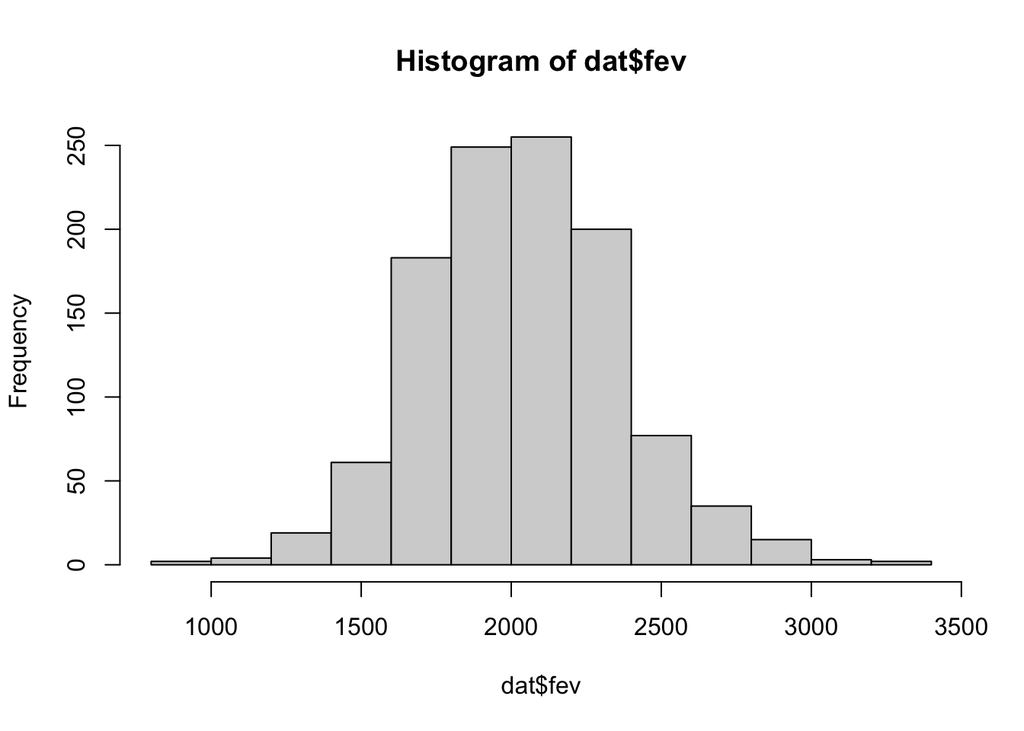

```r
hist(dat$fev) # FEV is normally distributed with a mean FEV of 2031.3
```

```r
summary(dat$fev)
```

```
   Min. 1st Qu.  Median    Mean 3rd Qu.    Max.    NA's
  984.8  1809.0  2022.7  2031.3  2249.7  3323.7      95
```

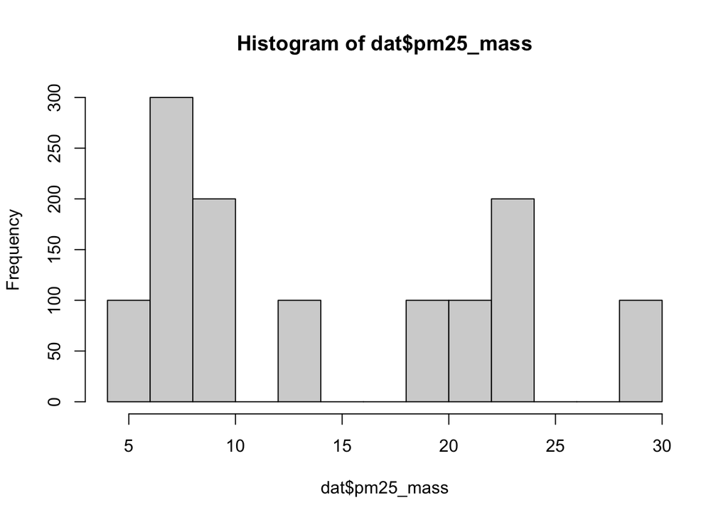

```r
hist(dat$pm25_mass) # there is only 1 pm25_mass values for each town
```

```r
unique(dat$pm25_mass)
```

```
 [1]  8.74  7.48 12.35  7.66  8.50  5.96 19.12 29.97 22.39 20.52  7.19 22.46
```

```r
# There are 12 unique values of pM25_mass, 12 unique towns for 1 value for each town
summary(dat$pm25_mass)
```

```
   Min. 1st Qu.  Median    Mean 3rd Qu.    Max.
  5.960   7.615  10.545  14.362  20.988  29.970
```

Fromt the output above we can confirmt that the data merged correctly. The new data set, dat, has 1200 obs. of 49 variables which is what we expected. There are 100 observations for each of the 12 towns. Most people in the study population don’t have asthma (998 without asthma vs 171 with asthma) We have a relatively even spread of males and females (610 females, 590 males). FEV is normally distributed with a mean FEV of 2031.3. There is only 1 pm25_mass values for each town. There are 12 unique values of pM25_mass, 12 unique towns for 1 value for each town.

### Imputation

We want to have 4 imputation groups. 1 for hispanic males, 1 for hispanic females, 1 for non hispanic males, and 1 for non Hispanic females. For continous variables we will take the mean for each group and impute any NAs within their respective groups. We will do the same for categorical variables expect we will use mode.

```r
# These are the groups we want to impute off of
dat[, Mode(mother_asthma, na.rm = TRUE), by = .(hispanic, male)]
```

```
   hispanic male V1
1:        0    0  0
2:        1    0  0
3:        1    1  0
4:        0    1  0
```

```r
dat[,mean(fev, na.rm = TRUE), by = .(hispanic, male)]
```

```
   hispanic male       V1
1:        0    0 1945.743
2:        1    0 1977.241
3:        1    1 2120.266
4:        0    1 2090.258
```

```r
#example for continuous
dat[, fev := fcoalesce(fev, mean(fev, na.rm = TRUE)),
    by = .(hispanic, male)]
# categorical
dat[, mother_asthma := fcoalesce(mother_asthma, Mode(mother_asthma, na.rm = TRUE)),by = .(hispanic, male)]
#dat
```

```r
# IMPUTE
#| echo: false
#categorical
dat[, asthma := fcoalesce(asthma, Mode(asthma, na.rm = TRUE)), by = .(hispanic, male)]
dat[, active_asthma := fcoalesce(active_asthma, Mode(active_asthma, na.rm = TRUE)), by = .(hispanic, male)]
dat[, father_asthma := fcoalesce(father_asthma, Mode(father_asthma, na.rm = TRUE)), by = .(hispanic, male)]
dat[, mother_asthma := fcoalesce(mother_asthma, Mode(mother_asthma, na.rm = TRUE)), by = .(hispanic, male)]
dat[, wheeze := fcoalesce(wheeze, Mode(wheeze, na.rm = TRUE)), by = .(hispanic, male)]
dat[, hayfever := fcoalesce(hayfever, Mode(hayfever, na.rm = TRUE)), by = .(hispanic, male)]
dat[, allergy := fcoalesce(allergy, Mode(allergy, na.rm = TRUE)), by = .(hispanic, male)]
dat[, educ_parent := fcoalesce(educ_parent, Mode(educ_parent, na.rm = TRUE)), by = .(hispanic, male)]
dat[, smoke := fcoalesce(smoke, Mode(smoke, na.rm = TRUE)), by = .(hispanic, male)]
dat[, pets := fcoalesce(pets, Mode(pets, na.rm = TRUE)), by = .(hispanic, male)]
dat[, gasstove := fcoalesce(gasstove, Mode(gasstove, na.rm = TRUE)), by = .(hispanic, male)]


#continuous
dat[, agepft := fcoalesce(agepft, mean(agepft, na.rm = TRUE)), by = .(hispanic, male)]
#dat[, height := fcoalesce(height, mean(height, na.rm = TRUE)), by = .(hispanic, male)]
dat[, height := fcoalesce(as.double(height), mean(as.double(height), na.rm = TRUE)), by = .(hispanic, male)]
dat[, weight := fcoalesce(as.double(weight), mean(as.double(weight), na.rm = TRUE)), by = .(hispanic, male)]
dat[, bmi := fcoalesce(bmi, mean(bmi, na.rm = TRUE)), by = .(hispanic, male)]
dat[, fev := fcoalesce(fev, mean(fev, na.rm = TRUE)), by = .(hispanic, male)]
dat[, fvc := fcoalesce(fvc, mean(fvc, na.rm = TRUE)), by = .(hispanic, male)]
dat[, mmef := fcoalesce(mmef, mean(mmef, na.rm = TRUE)), by = .(hispanic, male)]
```

### create bmi categories

```r
dat <- dat %>%
  mutate(
    obesity_level = case_when(
           bmi < 14 ~ 'underweight',
           bmi >= 14 & bmi < 22 ~ 'normal',
           bmi >=22 & bmi < 24 ~ 'overweight',
           bmi >= 24 ~ 'obese',
           TRUE ~ 'NA'
         )) %>%
  collect()
```

To make sure the variable is rightly coded, create a summary table that contains the minimum BMI, maximum BMI, and the total number of observations per category:

```r
summary_table <- dat %>%
  group_by(obesity_level) %>%
  summarize(
    min_bmi = min(bmi),
    max_bmi = max(bmi),
    total_observations = n()
  )

summary_table
```

```
# A tibble: 4 × 4
  obesity_level min_bmi max_bmi total_observations
  <chr>           <dbl>   <dbl>              <int>
1 normal           14.0    22.0                975
2 obese            24.0    41.3                103
3 overweight       22.0    24.0                 87
4 underweight      11.3    14.0                 35
```

### Create smoke/gas exposure variable and table

smoke_gas_exposure

smoke 1: exposed to second hand smoke in home , 0: not exposed

gas stove 1: presence of gas stove in home 0: not in home

```r
dat <- dat %>%
  mutate(
    smoke_gas_exposure = case_when(
           smoke ==1 & gasstove==1 ~ 'exp_both',
           smoke ==1 & gasstove==0 ~ 'exp_smoke',
           smoke ==0 & gasstove==1 ~ 'exp_gas',
           smoke ==0 & gasstove==0 ~ 'exp_none',
           TRUE ~ 'NA'
         )) %>%
  collect()
```

```r
summary_exp <- dat %>%
  group_by(smoke_gas_exposure) %>%
  summarize(
    total_observations = n()
  )

summary_exp
```

```
# A tibble: 4 × 2
  smoke_gas_exposure total_observations
  <chr>                           <int>
1 exp_both                          154
2 exp_gas                           791
3 exp_none                          219
4 exp_smoke                          36
```

Create four summary tables showing the average (or proportion, if binary) and sd of “Forced expiratory volume in 1 second (ml)” (an asthma indicator) by town, sex, obesity level, and “smoke_gas_exposure.”

```r
#Table of average FEV by town
sumtab1 <- dat %>%
  group_by(townname) %>%
  summarize(
    min_fev = min(fev),
    max_fev = max(fev),
    mean_fev_t = mean(fev),
    sd_fev_t = sd(fev),
    total_observations = n()
  )
sumtab1
```

```
# A tibble: 12 × 6
   townname      min_fev max_fev mean_fev_t sd_fev_t total_observations
   <chr>           <dbl>   <dbl>      <dbl>    <dbl>              <int>
 1 Alpine          1303.   3060       2087.     291.                100
 2 Atascadero      1146.   2921.      2076.     324.                100
 3 Lake Elsinore   1429.   3180.      2039.     304.                100
 4 Lake Gregory    1215.   2858.      2085.     320.                100
 5 Lancaster        996.   3324.      2003.     317.                100
 6 Lompoc           985.   3004.      2034.     351.                100
 7 Long Beach      1110.   2877.      1986.     319.                100
 8 Mira Loma       1210.   2826.      1985.     325.                100
 9 Riverside       1317.   2703       1990.     278.                100
10 San Dimas       1337.   2834.      2027.     319.                100
11 Santa Maria     1032    2839.      2026.     312.                100
12 Upland          1428.   3283.      2024.     343.                100
```

```r
#Table of gender proportions
sumtab2 <- dat %>%
  summarize(
    total_observations = n(),
    prop_male = sum(male == 1) / n(),
    prop_female = sum(male == 0) / n()
  )
sumtab2
```

```
  total_observations prop_male prop_female
1               1200 0.4916667   0.5083333
```

```r
#Table of average FEV by gender
sumtabmale <- dat %>%
  group_by(male) %>%
  summarize(
    min_fev = min(fev),
    max_fev = max(fev),
    mean_fev_t = mean(fev),
    sd_fev_t = sd(fev),
    total_observations = n()
  )
sumtabmale
```

```
# A tibble: 2 × 6
   male min_fev max_fev mean_fev_t sd_fev_t total_observations
  <int>   <dbl>   <dbl>      <dbl>    <dbl>              <int>
1     0    985.   3180.      1959.     312.                610
2     1   1146.   3324.      2104.     308.                590
```

```r
#Table of average FEV by obesity level
sumtab3 <- dat %>%
  group_by(obesity_level) %>%
  summarize(
    min_fev = min(fev),
    max_fev = max(fev),
    mean_fev_t = mean(fev),
    sd_fev_t = sd(fev),
    total_observations = n()
  )
sumtab3
```

```
# A tibble: 4 × 6
  obesity_level min_fev max_fev mean_fev_t sd_fev_t total_observations
  <chr>           <dbl>   <dbl>      <dbl>    <dbl>              <int>
1 normal           985.   3283.      2000.     295.                975
2 obese           1303.   3324.      2266.     325.                103
3 overweight      1605.   2939.      2224.     317.                 87
4 underweight      996.   2356.      1698.     303.                 35
```

```r
#Table of average FEV by Smoke/Gas Exposure
sumtab4 <- dat %>%
  group_by(smoke_gas_exposure) %>%
  summarize(
    min_fev = min(fev),
    max_fev = max(fev),
    mean_fev_t = mean(fev),
    sd_fev_t = sd(fev),
    total_observations = n()
  )
sumtab4
```

```
# A tibble: 4 × 6
  smoke_gas_exposure min_fev max_fev mean_fev_t sd_fev_t total_observations
  <chr>                <dbl>   <dbl>      <dbl>    <dbl>              <int>
1 exp_both             1317.   2764.      2025.     301.                154
2 exp_gas               985.   3324.      2023.     319.                791
3 exp_none             1032    3283.      2057.     329.                219
4 exp_smoke            1382.   3060       2056.     296.                 36
```

```r
#explaratory

table(dat$asthma) #Most people in the study population don't have asthma (1029 without asthma vs 171 with asthma)
```

```
   0    1
1029  171
```

```r
table(dat$male) # We have a relatively even spread of males and females (610 females, 590 males)
```

```
  0   1
610 590
```

```r
summary(dat$fev)
```

```
   Min. 1st Qu.  Median    Mean 3rd Qu.    Max.
  984.8  1827.6  2016.4  2030.1  2223.6  3323.7
```

```r
summary(dat$pm25_mass)
```

```
   Min. 1st Qu.  Median    Mean 3rd Qu.    Max.
  5.960   7.615  10.545  14.362  20.988  29.970
```

```r
summary(dat$bmi)
```

```
   Min. 1st Qu.  Median    Mean 3rd Qu.    Max.
  11.30   15.96   17.81   18.50   19.99   41.27
```

```r
summary(dat$smoke_gas_exposure)
```

```
   Length     Class      Mode
     1200 character character
```

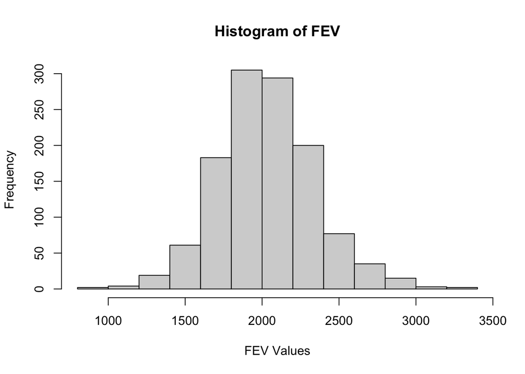

```r
hist(dat$fev, main = "Histogram of FEV", xlab = "FEV Values", ylab = "Frequency") # FEV is normally distributed with a mean FEV of 2031.3
```

[figure not shown]

```r
ggplot(data = dat, aes(x = townname, y = pm25_mass)) +
  geom_bar(stat = "identity", fill = "darkolivegreen1") +
  labs(x = "Town", y = "PM2.5 Mass") +
  theme_minimal() +
  theme(axis.text.x = element_text(angle = 45, hjust = 1))  +
  ggtitle("Mean PM2.5 Mass by Town")
```

```r
table(dat$smoke_gas_exposure)
```

```
 exp_both   exp_gas  exp_none exp_smoke
      154       791       219        36
```

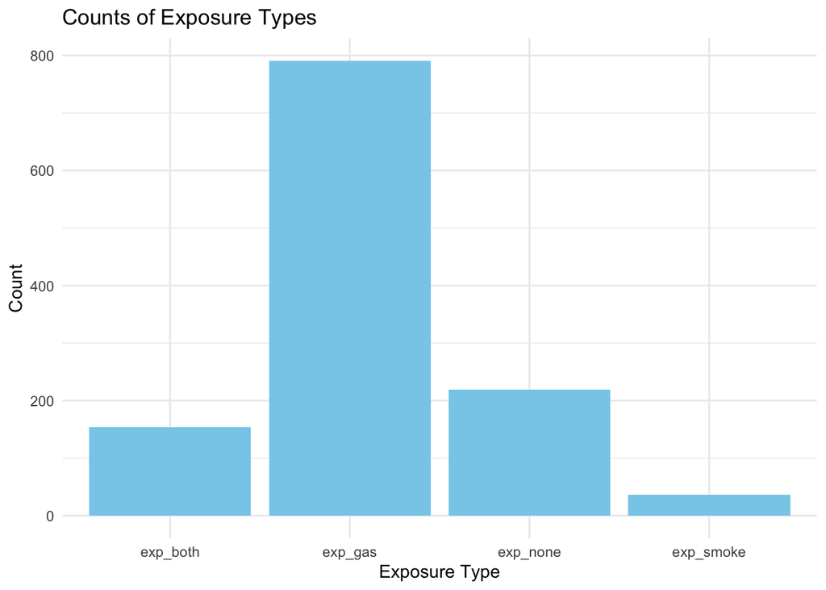

```r
data_counts <- data.frame(
  exposure = c("exp_both", "exp_gas", "exp_none", "exp_smoke"),
  count = c(154, 791, 219, 36)
)
ggplot(data = data_counts, aes(x = exposure, y = count)) +
  geom_bar(stat = "identity", fill = "skyblue") +
  labs(x = "Exposure Type", y = "Count") +
  theme_minimal() +
  ggtitle("Counts of Exposure Types")
```

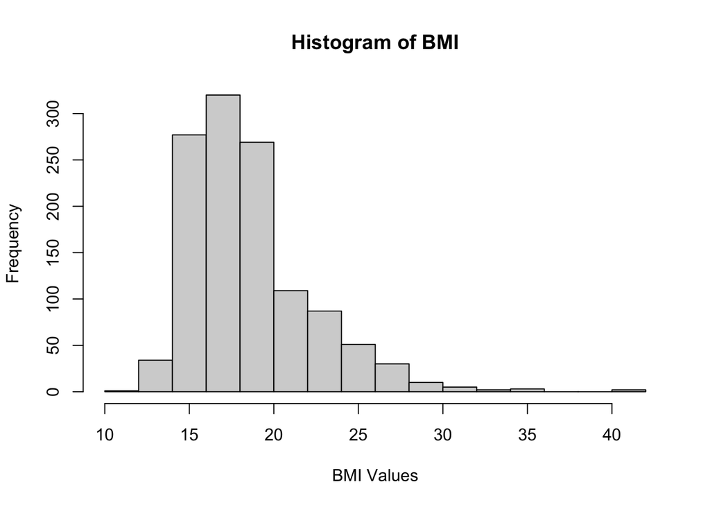

```r
hist(dat$bmi, main = "Histogram of BMI", xlab = "BMI Values", ylab = "Frequency")
```

```r
table(dat$obesity_level)
```

```
     normal       obese  overweight underweight
        975         103          87          35
```

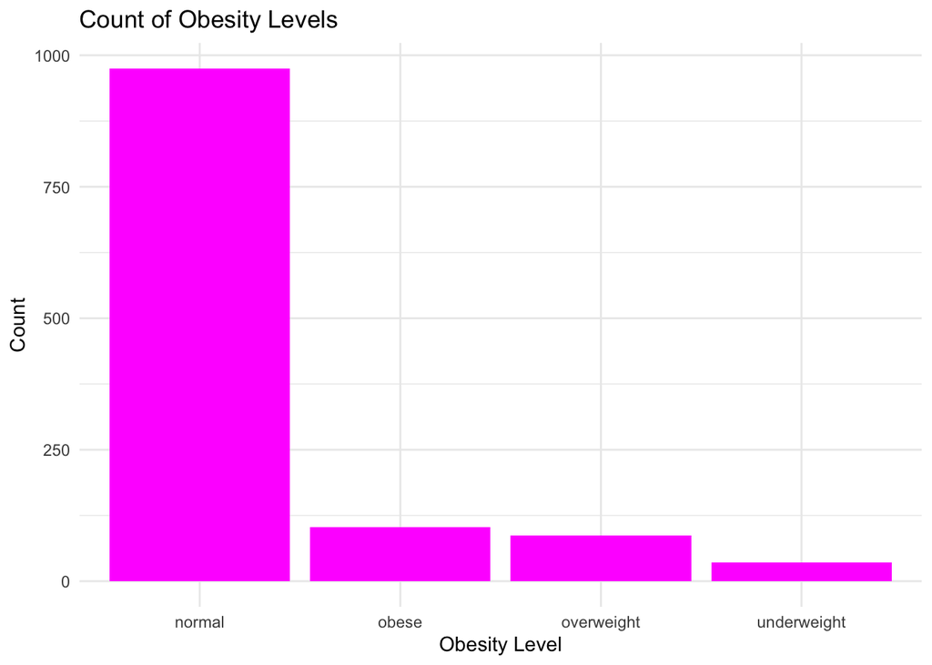

```r
obesity_counts <- data.frame(
  exposure = c("normal", "obese", "overweight", "underweight"),
  count = c(975, 103, 87, 35)
)
ggplot(data = obesity_counts, aes(x = exposure, y = count)) +
  geom_bar(stat = "identity", fill = "magenta") +
  labs(x = "Obesity Level", y = "Count") +
  theme_minimal() +
  ggtitle("Count of Obesity Levels ")
```

```r
unique(dat$pm25_mass)
```

```
 [1]  8.74  7.48 12.35  7.66  8.50  5.96 19.12 29.97 22.39 20.52  7.19 22.46
```

```r
# There are 12 unique values of pM25_mass, 12 unique towns for 1 value for each town
```

### Correlations

```r
cont_vars <- c("fev", "bmi", "pm25_mass")
subset_dat <- dat[, ..cont_vars]
correlation_matrix <- cor(subset_dat)

correlation_matrix
```

```
                  fev         bmi   pm25_mass
fev        1.00000000  0.35711203 -0.07341317
bmi        0.35711203  1.00000000 -0.03864875
pm25_mass -0.07341317 -0.03864875  1.00000000
```

```r
model_obese <- lm(fev ~ obesity_level, data = dat)
summary(model_obese)
```

```
Call:
lm(formula = fev ~ obesity_level, data = dat)

Residuals:
     Min       1Q   Median       3Q      Max
-1014.95  -191.55   -19.47   178.41  1283.58

Coefficients:
                         Estimate Std. Error t value Pr(>|t|)
(Intercept)               1999.79       9.60 208.305  < 2e-16 ***
obesity_levelobese         266.36      31.06   8.576  < 2e-16 ***
obesity_leveloverweight    224.53      33.54   6.694 3.33e-11 ***
obesity_levelunderweight  -301.47      51.57  -5.846 6.51e-09 ***
---
Signif. codes:  0 '***' 0.001 '**' 0.01 '*' 0.05 '.' 0.1 ' ' 1

Residual standard error: 299.8 on 1196 degrees of freedom
Multiple R-squared:  0.1136,    Adjusted R-squared:  0.1113
F-statistic: 51.08 on 3 and 1196 DF,  p-value: < 2.2e-16
```

```r
model_exp <- lm(fev ~ smoke_gas_exposure, data = dat)
summary(model_exp)
```

```
Call:
lm(formula = fev ~ smoke_gas_exposure, data = dat)

Residuals:
    Min      1Q  Median      3Q     Max
-1037.8  -205.3   -12.0   190.7  1301.0

Coefficients:
                            Estimate Std. Error t value Pr(>|t|)
(Intercept)                 2024.778     25.633  78.991   <2e-16 ***
smoke_gas_exposureexp_gas     -2.107     28.017  -0.075    0.940
smoke_gas_exposureexp_none    31.915     33.453   0.954    0.340
smoke_gas_exposureexp_smoke   30.936     58.888   0.525    0.599
---
Signif. codes:  0 '***' 0.001 '**' 0.01 '*' 0.05 '.' 0.1 ' ' 1

Residual standard error: 318.1 on 1196 degrees of freedom
Multiple R-squared:  0.001868,  Adjusted R-squared:  -0.0006354
F-statistic: 0.7462 on 3 and 1196 DF,  p-value: 0.5246
```

```r
model_pm25 <- lm(fev ~ pm25_mass, data = dat)
summary(model_pm25)
```

```
Call:
lm(formula = fev ~ pm25_mass, data = dat)

Residuals:
     Min       1Q   Median       3Q      Max
-1070.63  -206.57   -13.33   195.87  1277.65

Coefficients:
            Estimate Std. Error t value Pr(>|t|)
(Intercept) 2073.452     19.309 107.383   <2e-16 ***
pm25_mass     -3.016      1.184  -2.548    0.011 *
---
Signif. codes:  0 '***' 0.001 '**' 0.01 '*' 0.05 '.' 0.1 ' ' 1

Residual standard error: 317.3 on 1198 degrees of freedom
Multiple R-squared:  0.005389,  Adjusted R-squared:  0.004559
F-statistic: 6.492 on 1 and 1198 DF,  p-value: 0.01096
```

From the tests above we can see that FEV and PM25_MASS are significantly associated (p=0.011). BMI and FEV have a positive correlation coefficient of 0.357. FEV and obesity are significantly associated with a p<0.0001. FEV and smoke/gas exposure were not found to be significantly associated p=0.52.

## **Visualization**

### 1. Facet plot showing scatterplots with regression lines of BMI vs FEV by “townname”.

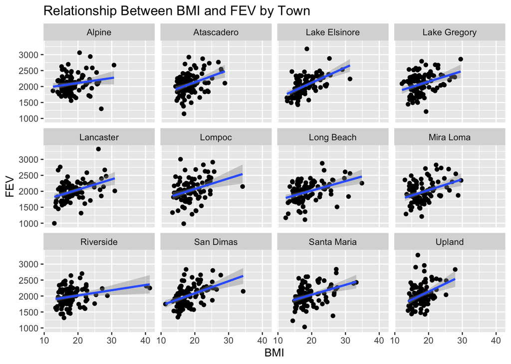

```r
ggplot(dat, aes(x=bmi, y=fev)) +
  geom_point() +
  geom_smooth(method="lm") +
  facet_wrap(~townname, nrow=3) +
  labs(x = "BMI", y = "FEV", title = "Relationship Between BMI and FEV by Town")
```

### 2. Stacked histograms of FEV by BMI category and FEV by smoke/gas exposure. Use different color schemes than the ggplot default.

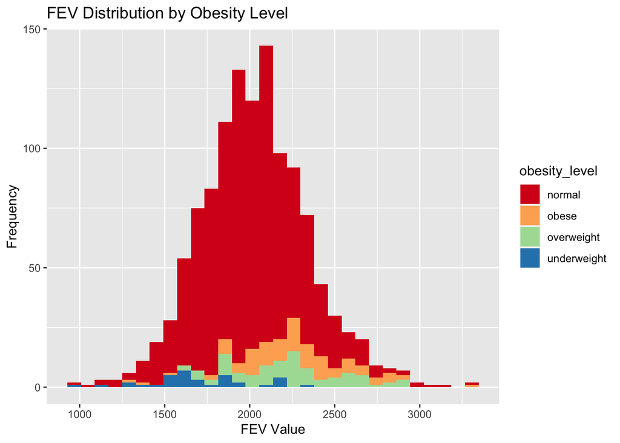

```r
ggplot(dat, aes(x=fev, fill=obesity_level)) +
  geom_histogram() +
  scale_fill_brewer(palette = 'Spectral')+
  labs(x = "FEV Value", y = "Frequency", title = "FEV Distribution by Obesity Level")
```

This graph displays the range of FEV values. The color represents the obesity level categories. We can see that those in underweight category have lower FEV values compared to the other obesity categories. The normal obesity group is centered around the mean FEV, while overweight and obese have higher FEV values.

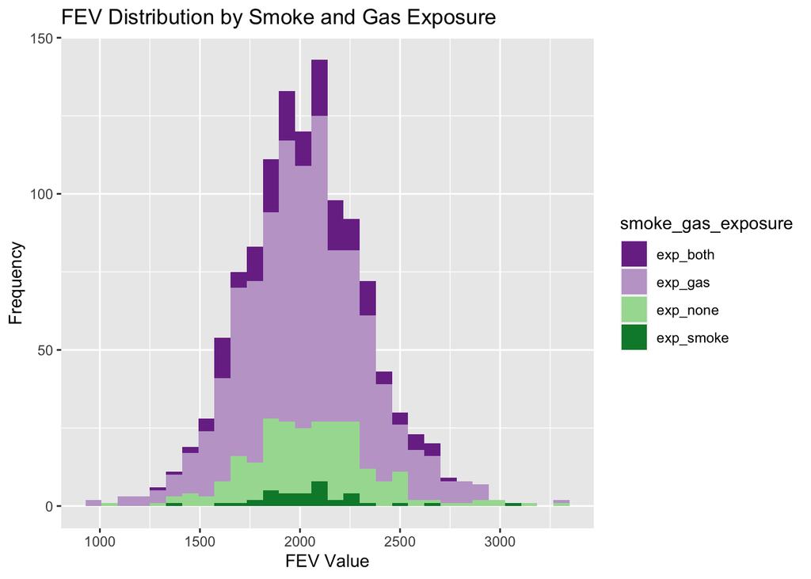

```r
ggplot(dat, aes(x=fev, fill=smoke_gas_exposure)) +
  geom_histogram() +
  scale_fill_brewer(palette = 'PRGn')+
  labs(x = "FEV Value", y = "Frequency", title = "FEV Distribution by Smoke and Gas Exposure")
```

In this graph we are visualizing the distribution of FEV values among different exposure categories. It appears that the FEV distribution is about the same across all categories. This is a similar conclusion that we made from the statistical test above.

### 3. Barchart of BMI by smoke/gas exposure.

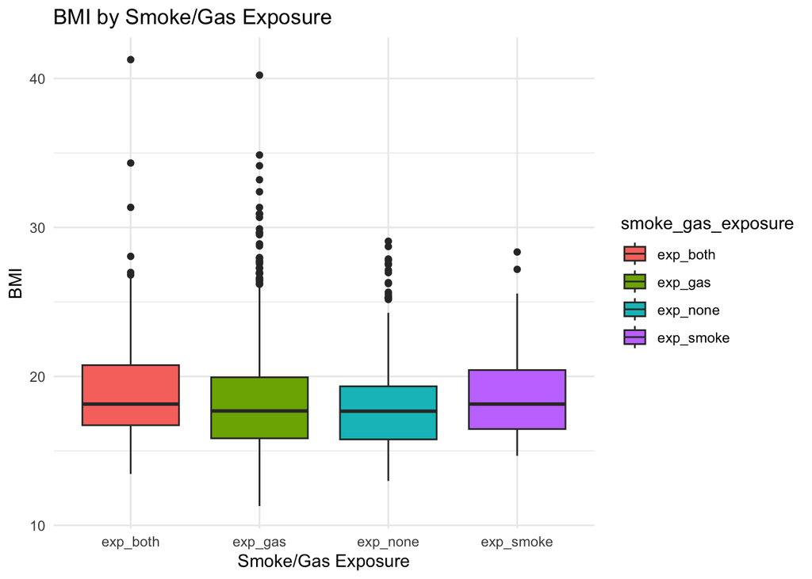

```r
#boxplot
ggplot(dat, aes(x = smoke_gas_exposure, y = bmi, fill = smoke_gas_exposure)) +
  geom_boxplot() +
  labs(
    title = "BMI by Smoke/Gas Exposure",
    x = "Smoke/Gas Exposure",
    y = "BMI"
  ) +
  theme_minimal()
```

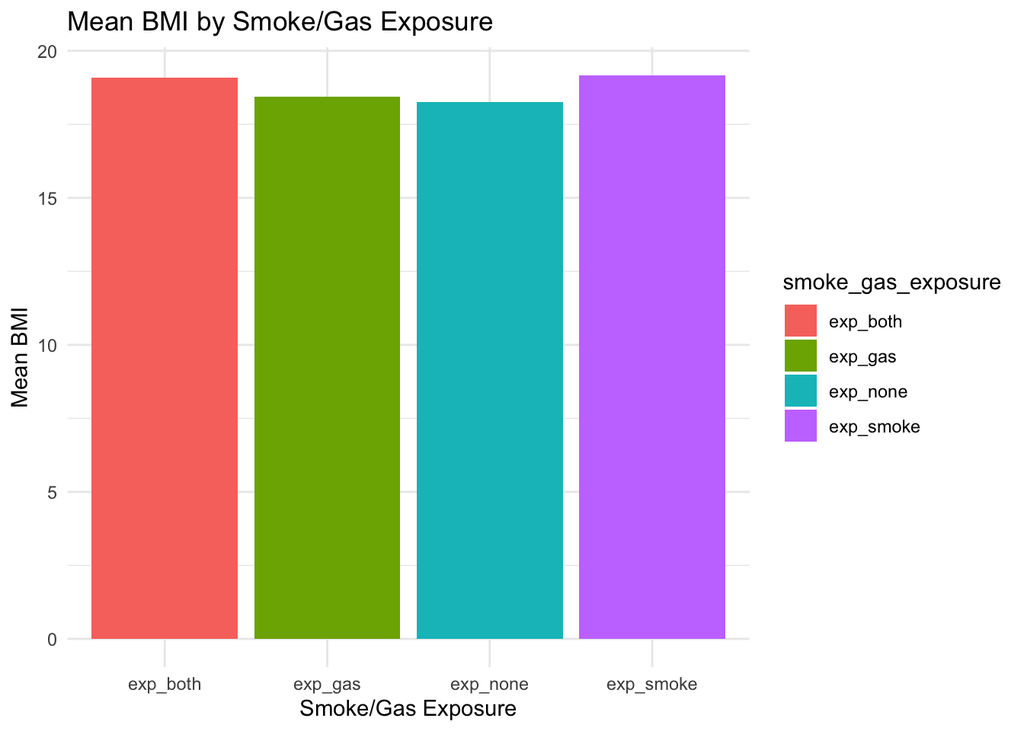

```r
# bar chart
mean_bmi <- dat %>%
  group_by(smoke_gas_exposure) %>%
  summarize(mean_bmi = mean(bmi))

ggplot(mean_bmi, aes(x = smoke_gas_exposure, y = mean_bmi, fill = smoke_gas_exposure)) +
  geom_col(position = "dodge") +
  labs(
    title = "Mean BMI by Smoke/Gas Exposure",
    x = "Smoke/Gas Exposure",
    y = "Mean BMI"
  ) +
  theme_minimal()
```

The boxplot shows that there is not a big difference in BMI between the different exposure groups. However exposure to gas and gas+smoke had some higher BMI outliers. The bar graph displays the mean BMI by exposure group, we also see here that there is not a big difference in mean BMI between the exposure groups.

```r
mean_bmi <- dat %>%
  group_by(smoke_gas_exposure) %>%
  summarize(mean_bmi = mean(bmi, na.rm = TRUE))
```

### 4. Statistical summary graphs of FEV by BMI and FEV by smoke/gas exposure category.

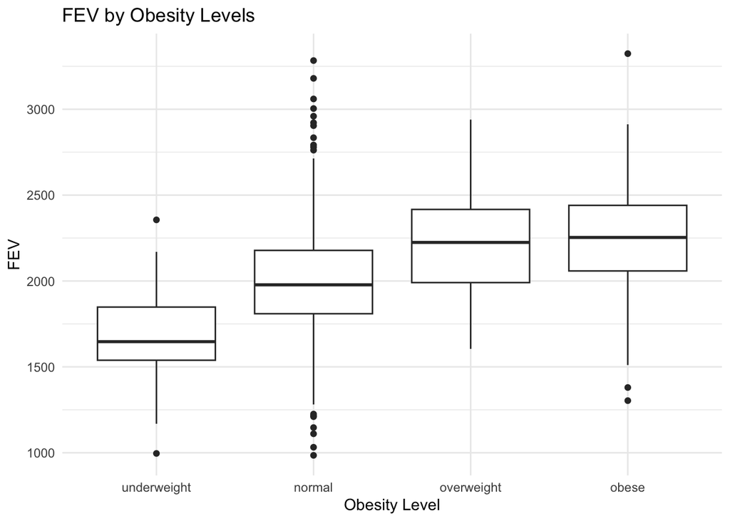

```r
obesity_order <- c("underweight", "normal", "overweight", "obese")
ggplot(dat, aes(x = factor(obesity_level, levels = obesity_order), y = fev)) +
  geom_boxplot() +
  labs(
    title = "FEV by Obesity Levels",
    x = "Obesity Level",
    y = "FEV"
  ) +
  theme_minimal()
```

This boxplot shows the distribution of FEV by obesity level. We can see there is a steady increase of FEV as the obesity level increases. We can see there is a large difference between the median underweight FEV value (around 1700) compared to the obese category (around 2250).

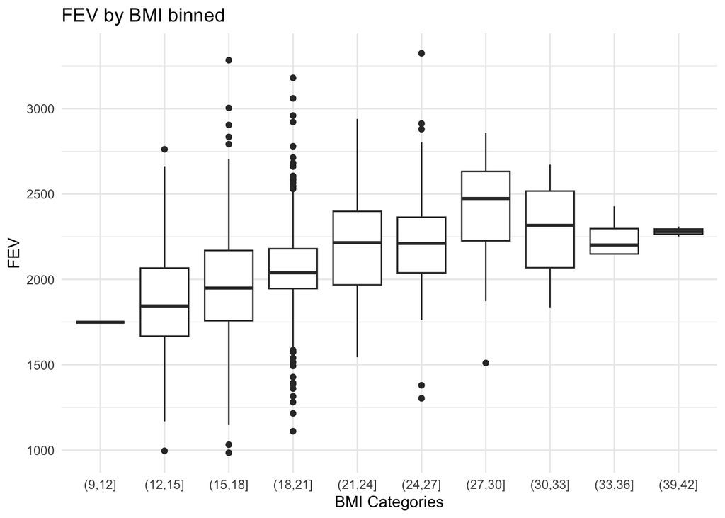

```r
ggplot(dat, aes(x = cut(bmi, breaks = seq(0, 50, by = 3)), y = fev)) +
  geom_boxplot() +
  labs(
    title = "FEV by BMI binned",
    x = "BMI Categories",
    y = "FEV"
  ) +
  theme_minimal()
```

This boxplot is similar to the one above, but it has smaller bins for BMI, enabling a more detailed examination of the distribution breakdown. It reveals a consistent upward trend in FEV as BMI increments. With the highest FEV values at the 27-30 BMI range and then the FEV plateaus

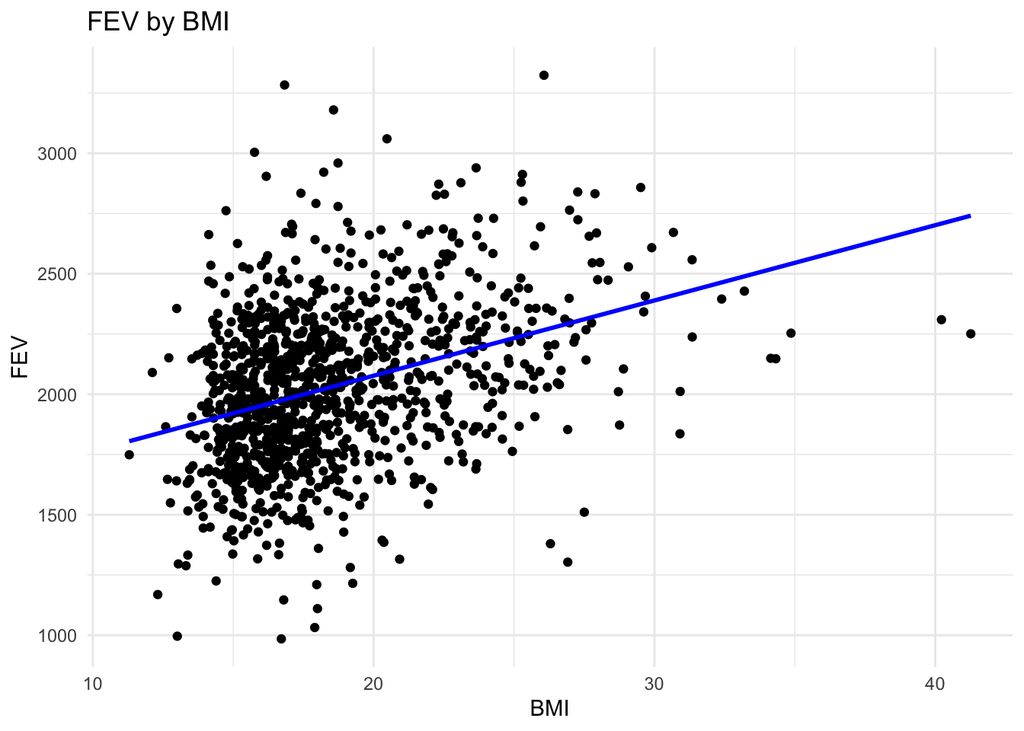

```r
ggplot(dat, aes(x = bmi, y = fev)) +
  geom_point() +
  geom_smooth(method = "lm", se = FALSE, color = "blue") +
  labs(
    title = "FEV by BMI",
    x = "BMI",
    y = "FEV"
  ) +
  theme_minimal()
```

Here we can see FEV and BMI are positively associated, the FEV increases as BMI increases.

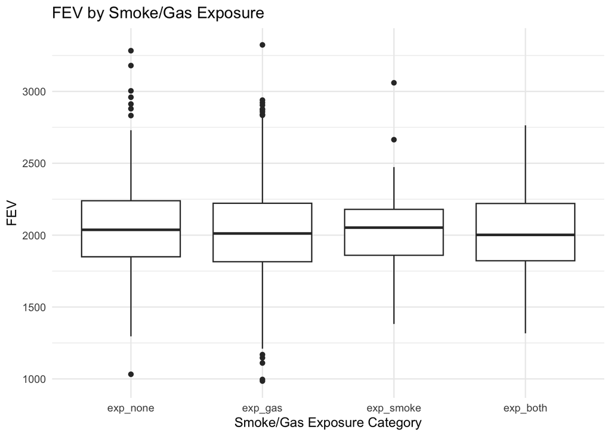

```r
exposure_order <- c("exp_none", "exp_gas", "exp_smoke", "exp_both")
ggplot(dat, aes(x = factor(smoke_gas_exposure, levels = exposure_order), y = fev)) +
  geom_boxplot() +
  labs(
    title = "FEV by Smoke/Gas Exposure",
    x = "Smoke/Gas Exposure Category",
    y = "FEV"
  ) +
  theme_minimal()
```

FEV levels are relatively similar across smoke/gas exposure groups. This agrees with our analysis above.

### 5. A leaflet map showing the concentrations of PM2.5 mass in each of the CHS communities.

```r
paletteNum <- colorNumeric(c('darkgreen','goldenrod','brown'), domain = dat$pm25_mass)


leaflet(dat) %>%
  addProviderTiles('CartoDB.Positron') %>%
  addCircles(lat = ~lat, lng = ~lon, opacity = 1, fillOpacity = 0.8, radius = 400, color = ~paletteNum(dat$pm25_mass)) %>%
  addLegend(
    pal = paletteNum,
    values = ~dat$pm25_mass,
    title = "PM2.5 Mass",
    opacity = 1,
    position = "bottomright",
    labFormat = labelFormat(suffix = " µg/m³")
  )
```

[interactive chart not shown]

### 6. Choose a visualization to examine whether PM2.5 mass is associated with FEV.

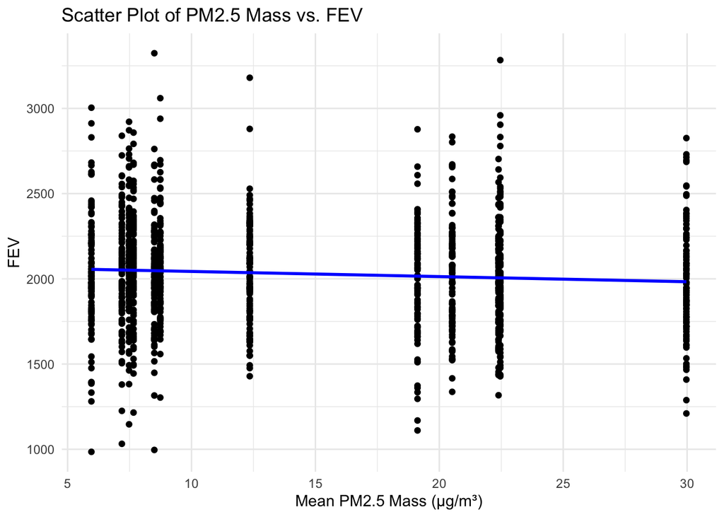

```r
ggplot(dat, aes(x = pm25_mass, y = fev)) +
  geom_point() +
  geom_smooth(method = "lm", se = FALSE, color = "blue") +
  labs(
    x = "Mean PM2.5 Mass (µg/m³)",
    y = "FEV",
    title = "Scatter Plot of PM2.5 Mass vs. FEV"
  ) +
  theme_minimal()
```

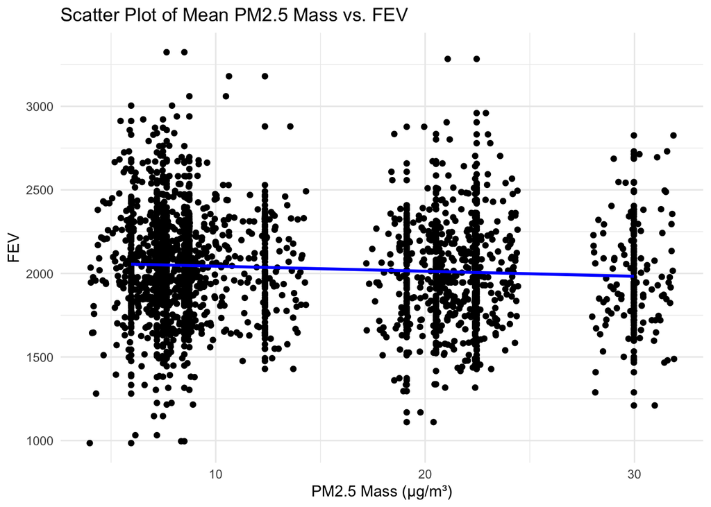

```r
#jitter added for visualization
ggplot(dat, aes(x = pm25_mass, y = fev)) +
  geom_jitter(width = 2, height = 0.1) +
  geom_point() +
  geom_smooth(method = "lm", se = FALSE, color = "blue") +  # Add regression line
  labs(
    x = "PM2.5 Mass (µg/m³)",
    y = "FEV",
    title = "Scatter Plot of Mean PM2.5 Mass vs. FEV"
  ) +
  theme_minimal()
```

```r
cor(dat$pm25_mass, dat$fev)
```

```
[1] -0.07341317
```

```r
cor(dat$smoke, dat$fev)
```

```
[1] 0.0006795663
```

```r
cor(dat$pm25_mass, dat$fev)
```

```
[1] -0.07341317
```

```r
cor(dat$weight, dat$fev)
```

```
[1] 0.5306235
```

Here we see that weight and FEV have a correlation coefficient of 0.53. This means that as weight tends to increase, FEV also tends to increase, and vice versa, although the relationship is not extremely strong.

```r
oneway.test(fev ~pm25_mass,
            data=dat)
```

```
    One-way analysis of means (not assuming equal variances)

data:  fev and pm25_mass
F = 1.394, num df = 11.00, denom df = 467.94, p-value = 0.1721
```

```r
oneway.test(fev ~smoke,
            data=dat)
```

```
    One-way analysis of means (not assuming equal variances)

data:  fev and smoke
F = 0.0006106, num df = 1.00, denom df = 277.62, p-value = 0.9803
```

```r
oneway.test(fev ~gasstove,
            data=dat)
```

```
    One-way analysis of means (not assuming equal variances)

data:  fev and gasstove
F = 2.1765, num df = 1.00, denom df = 394.56, p-value = 0.1409
```

## Conclusion

In this analysis of the CHS (Children’s Health Study) data, we conducted a comprehensive examination of various factors related to lung function and air quality. Here are the key findings and conclusions drawn from the analysis:

Imputation was performed to handle missing values within specific groups. Continuous variables were imputed using the mean value of their respective groups, while categorical variables were imputed with the mode of their groups. Obesity level categories were created based on BMI values. Smoke and gas exposure variables were combined to create categories based on exposure status.